# Non-parametric tests & Discrete data

PSM 2

Bennett Kleinberg

5 Feb 2019

Probability, Statistics & Modeling II

### Lecture 5

Non-paramtric tests & discrete data

### What question do you have?

## Today

- What to do if the parametric assumptions violated
- Non-parametric equivalents
- Discrete data (chisquare, loglinear model)

### Non-parametric tests

## Non Parametric tests

Parametric assumptions

- Independence of errors
- Homogeneity of variance
- Normality

## Independence of errors

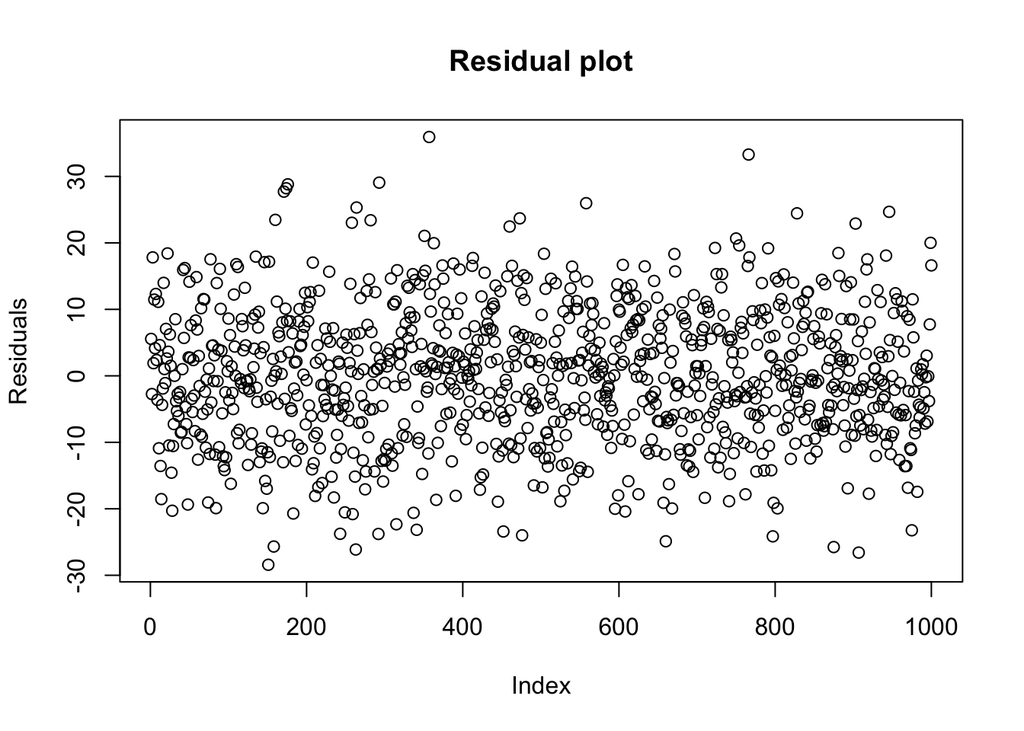

## Independence of errors

- errors (estimated through residuals) should be ‘randomly’ distributed around 0
- … for all observations
- rule to investigate this: correlation
  - between residuals and predictor variable(s)

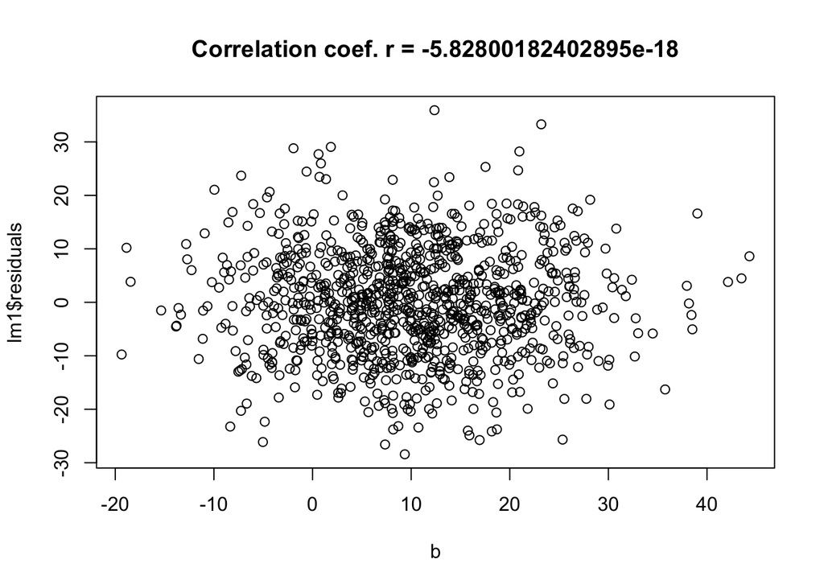

## Homegeneity of variance

Also called: homoscedasticity

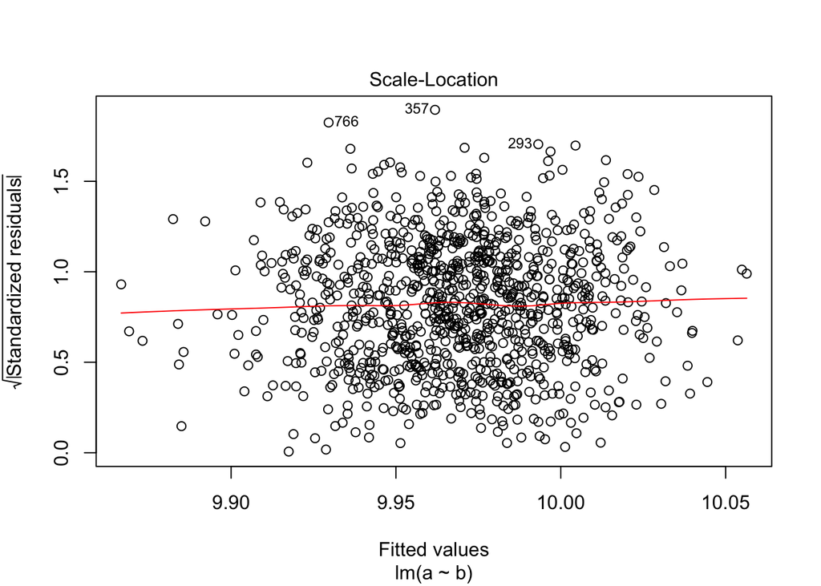

## Homegeneity of variance

Can be tested with:

- Levene’s Test `car:leveneTest(...)`
- Breush Pagan Test `lmtest::bptest(...)`
- both have H0 = data is homoscedastic

## Normality

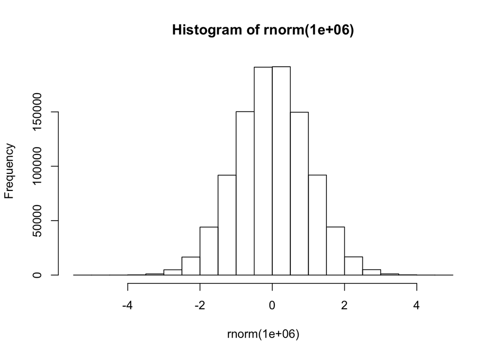

## Normality

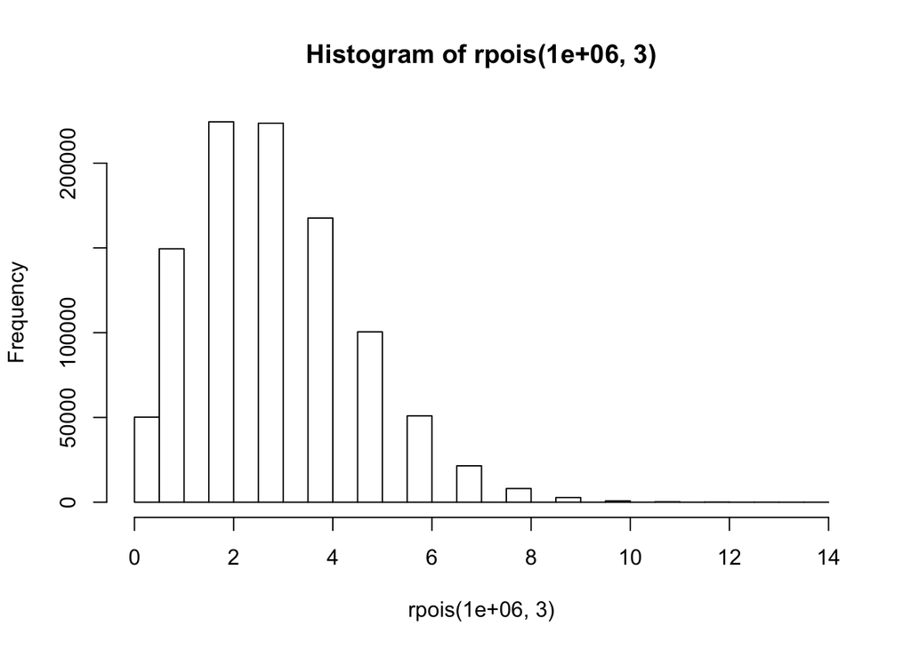

## Normality

Normally met when:

- sample size is considerably large (e.g. n > 50)

Can be tested with:

- Kolmogorov-Smirnov Test
- Shapiro’s Test `shapiro.test()`
- both have H0 = data is normally distributed

### What to do if these are violated?

## Violation of parametric assumptions

| Assumption | Test | Potential fix |
| --- | --- | --- |
| Independence of errors | Resiudal-predictor plot, correlation | Autocorrelation-sensitive methods |
| Homoscedasticity | Levene’s Test, plot | [Box-Cox transformation](https://datascienceplus.com/how-to-detect-heteroscedasticity-and-rectify-it/) |
| Normality | K-S test, Shapiro’s Test | Transforming data |

## Non-paramtric tests: Correlation

Parametric case:

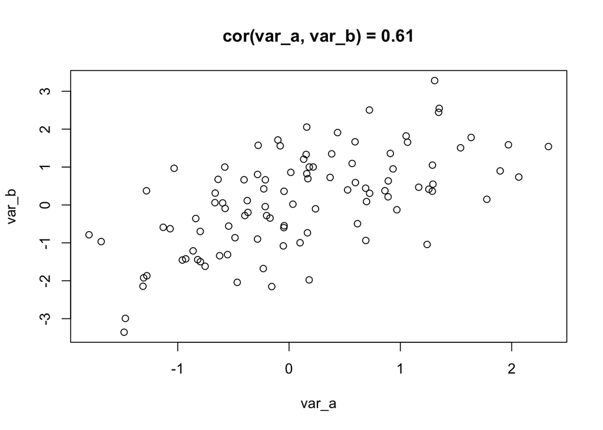

## Non-paramtric tests: Correlation

Non-parametric case

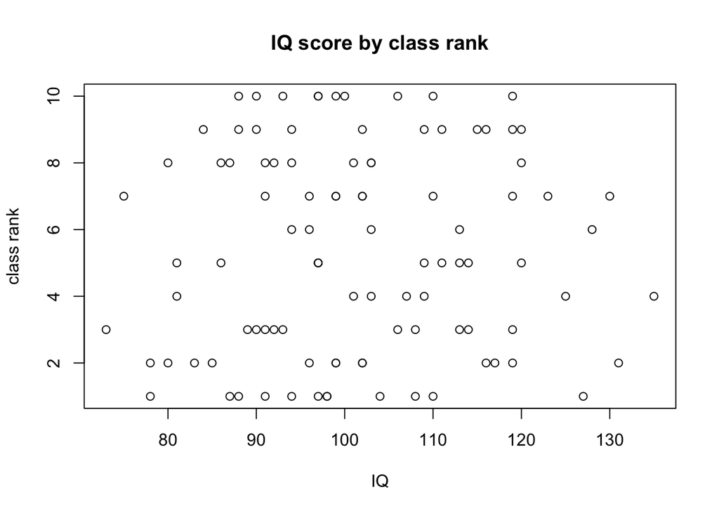

Problem: class rank not parametric (e.g. not normally distributed)

## Non-paramtric tests: Correlation

**Spearman’s correlation test**

Idea:

- rank the data
- run correlation on ranked data

```r
cor.test(iq, class_rank, method = 'spearman')
```

```
##
##  Spearman's rank correlation rho
##
## data:  iq and class_rank
## S = 158810, p-value = 0.6421
## alternative hypothesis: true rho is not equal to 0
## sample estimates:
##        rho
## 0.04704638
```

## Non-paramtric tests: T-tests

Parametric case: Independent samples t-test

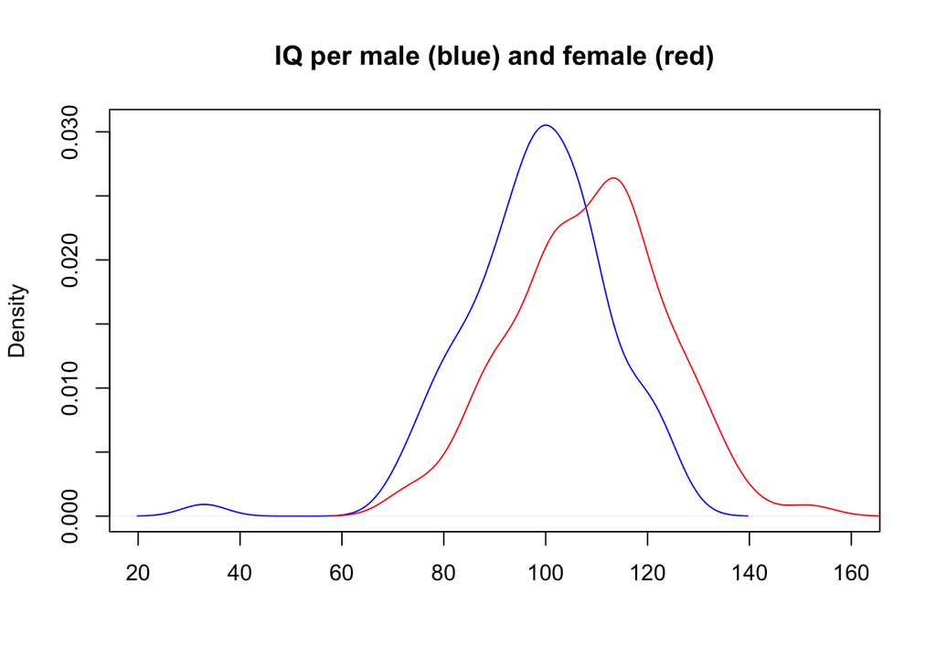

## Non-paramtric tests: T-tests

Parametric case: Independent samples t-test

```r
t.test(males, females)
```

```
##
##  Welch Two Sample t-test
##
## data:  males and females
## t = -5.0547, df = 197.52, p-value = 9.796e-07
## alternative hypothesis: true difference in means is not equal to 0
## 95 percent confidence interval:
##  -14.496541  -6.359724
## sample estimates:
## mean of x mean of y
##  98.14252 108.57065
```

## Non-paramtric tests: T-tests

Non-parametric case: Independent samples t-test

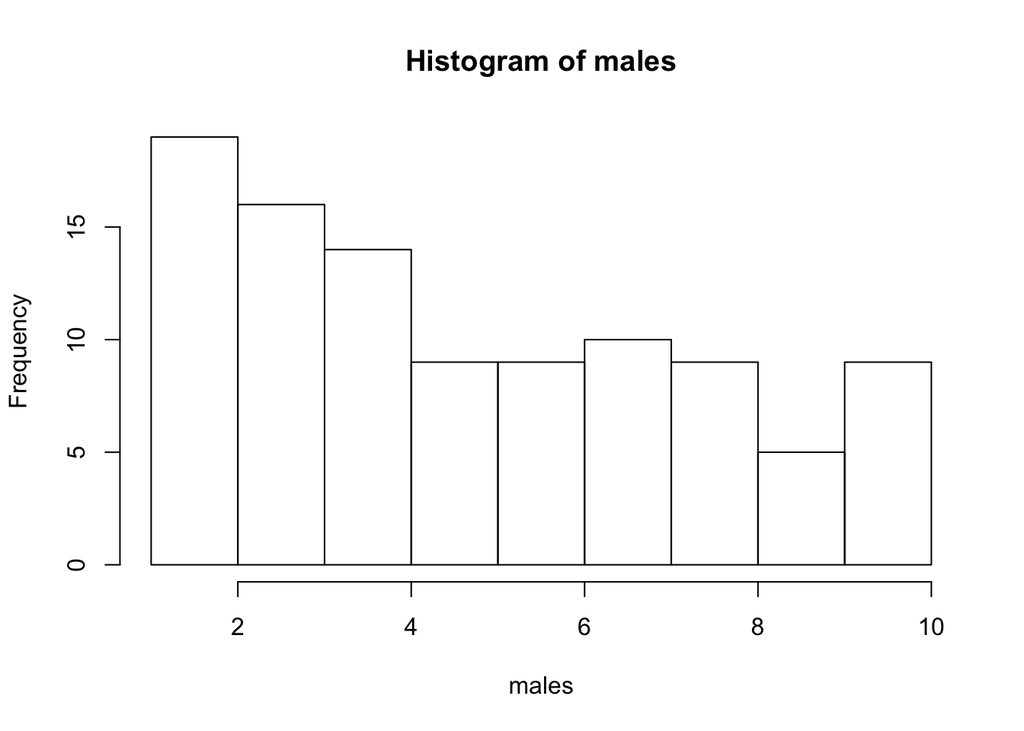

Problem: variable “rank” not parametric (e.g. not normally distributed)

## Non-paramtric tests: T-tests

**Wilcoxon Rank Sum Test**

Idea:

- rank the data
- sum the ranks
- use the smallest rank sum as test statistic
- assess the significance of the test-statistic

| males | rank.males. | females | rank.females. |
| --- | --- | --- | --- |
| 3 | 27.5 | 8 | 75.5 |
| 3 | 27.5 | 7 | 65.0 |
| 8 | 82.0 | 2 | 15.5 |
| 6 | 63.0 | 3 | 25.5 |
| 7 | 72.5 | 8 | 75.5 |
| 10 | 96.0 | 1 | 5.5 |

## Wilcoxon rank sum test

```r
wilcox.test(males, females)
```

```
##
##  Wilcoxon rank sum test with continuity correction
##
## data:  males and females
## W = 4564.5, p-value = 0.2853
## alternative hypothesis: true location shift is not equal to 0
```

For the non-parametric “dependent t-test”, you’d have to use the ‘paired’ argument (same is in the `t.test` function).

## Non-paramtric tests: ANOVA

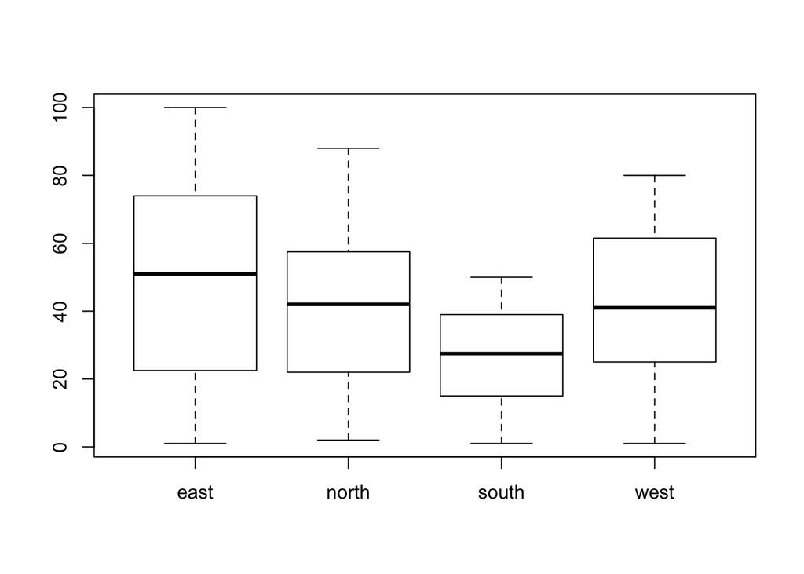

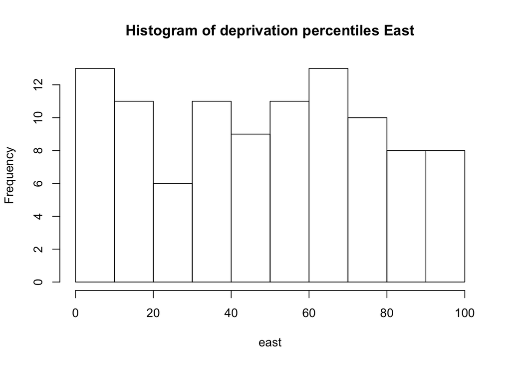

## Non-paramtric tests: ANOVA

**The Kruskal-Wallis Test**

- rank the data
- sum the ranks per group
- apply [Kruskal-Wallis formula](https://en.wikipedia.org/wiki/Kruskal%E2%80%93Wallis_one-way_analysis_of_variance#Method) to calculate the test-statistic $H$
- test significance of H

## Non-paramtric tests: ANOVA

```r
kruskal.test(deprivation ~ area, data = deprivation)
```

```
##
##  Kruskal-Wallis rank sum test
##
## data:  deprivation by area
## Kruskal-Wallis chi-squared = 40.92, df = 3, p-value = 6.8e-09
```

### Discrete data

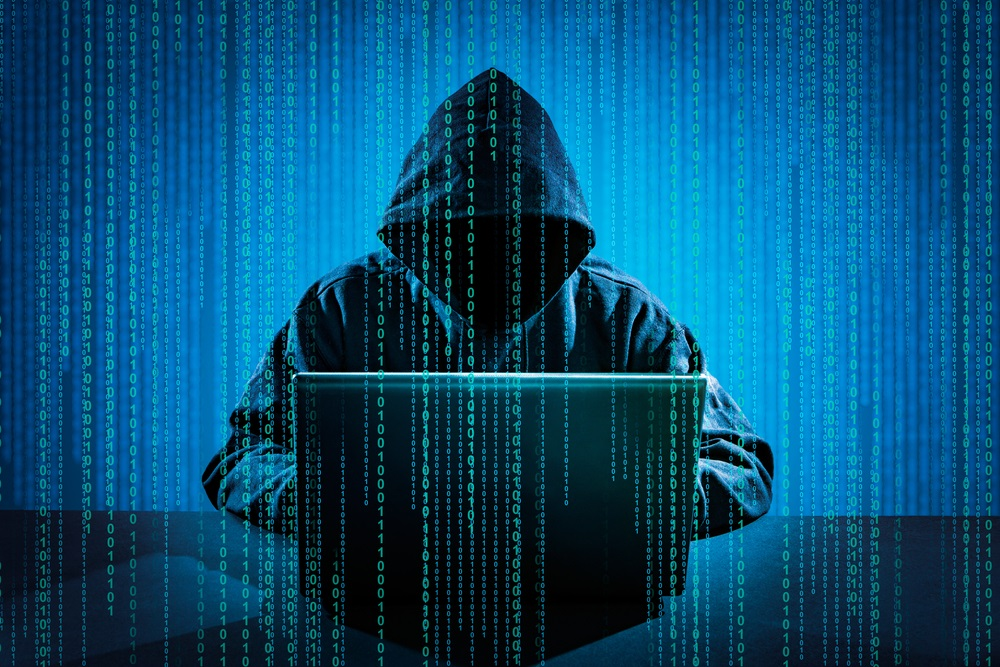

## Problem

|  | No anti-virus software | Anti-virus software |
| --- | --- | --- |
| Hacked | 300 | 250 |
| Not hacked | 200 | 250 |

- uni-directionality?
- bi-directionality?
- third variable?

**Association test**

## 2 by 2 tables

**Chi-square test**

|  | No anti-virus software | Anti-virus software | Sum |
| --- | --- | --- | --- |
| Hacked | 300 | 250 | 550 |
| Not hacked | 200 | 250 | 450 |
| Sum | 500 | 500 | 1000 |

## Discrete data

Idea of the Chi-square test:

- Observed values $O$
- Expected values (if there were no association) $E$
- rows: $i$
- columns: $j$

$E_i,_j = (total_i * total_j)/total$

## Expected values

$E_i,_j = (total_i * total_j)/total$

|  | No anti-virus software | Anti-virus software | Sum |
| --- | --- | --- | --- |
| Hacked | ? | ? | 550 |
| Not hacked | ? | ? | 450 |
| Sum | 500 | 500 | 1000 |

Example: cell [hacked, no anti-virus software] –> cell [1,1]

$E_i,_j = (total_i * total_j)/total$

$ = (550 * 500)/1000$

$ = 275$

Expected values

|  | No anti-virus software | Anti-virus software | Sum |
| --- | --- | --- | --- |
| Hacked | 275 | 275 | 550 |
| Not hacked | 225 | 225 | 450 |
| Sum | 500 | 500 | 1000 |

## Calculating the Chi-square value

$\chi^2 = \sum\frac{(O - E^2)}{E}$

For cell[2,1]:

$cell[2,1] = \frac{(200-225)^2}{225} = \frac{-25^2}{225} = \frac{625}{225} = 2.78$

## Calculating the Chi-square value

- Repeat procedure for all cells
- Sum the values

|  | No anti-virus software | Anti-virus software |
| --- | --- | --- |
| Hacked | 300 (275) | 250 (275) |
| Not hacked | 200 (225) | 250 (225) |

- Null-hypothesis: there is no association between the two factors
- Alt. hypothesis: there is a significant association

## The Chi-square test for 2*2 tables

```
##
##  Pearson's Chi-squared test
##
## data:  data1
## X-squared = 10.101, df = 1, p-value = 0.001482
```

## Now what?

> There is a significant association between being hacked (hacked vs not hacked) and the use of anti-virus software (no anti-virus software vs anit-virus software), X<sup>2</sup>(1) = 10.10, *p* = .001.

But where does this association stem from? What drives it?

|  | No anti-virus software | Anti-virus software |
| --- | --- | --- |
| Hacked | 300 | 250 |
| Not hacked | 200 | 250 |

## Standardized residuals

Interpret as:

- the number of standard deviations away from zero
- we know: +/- 2.58 SD = 0.01 and 0.99 percentile

```r
knitr::kable(chisq.test(data1, correct = F)$stdres)
```

|  | No anti-virus software | Anti-virus software |
| --- | --- | --- |
| Hacked | 3.178209 | -3.178209 |
| Not hacked | -3.178209 | 3.178209 |

## Interpretation

|  | No anti-virus software | Anti-virus software |
| --- | --- | --- |
| Hacked | 3.18 (O > E) | -3.18 (O < E) |
| Not hacked | -3.18 (O < E) | 3.18 (O > E) |

## From 2-by-2 to r-by-c

|  | Non AV | standard AV | premium AV |
| --- | --- | --- | --- |
| No access | 200 | 250 | 150 |
| Files stolen | 400 | 300 | 200 |
| Ransomware | 350 | 150 | 150 |

## Extension of the 2 by 2 approach

```r
knitr::kable(addmargins(data2, c(1,2)))
```

|  | Non AV | standard AV | premium AV | Sum |
| --- | --- | --- | --- | --- |
| No access | 200 | 250 | 150 | 600 |
| Files stolen | 400 | 300 | 200 | 900 |
| Ransomware | 350 | 150 | 150 | 650 |
| Sum | 950 | 700 | 500 | 2150 |

Same steps:

- for each cell $\frac{(O - E^2)}{E}$
- sum to obtain $\chi^2$
- assess *omnibus* significance
- follow-up interpretation

## (O - E)^2/E

|  | Non AV | standard AV | premium AV |
| --- | --- | --- | --- |
| No access | 15.99 | 15.29 | 0.78 |
| Files stolen | 0.01 | 0.17 | 0.41 |
| Ransomware | 13.73 | 17.95 | 0.01 |

## Extension of the 2 by 2 approach

```
##
##  Pearson's Chi-squared test
##
## data:  data2
## X-squared = 64.344, df = 4, p-value = 3.537e-13
```

Follow-up tests for the interpretation.

–> What drives the sign. association?

## Intepreting the r-by-c extension

```r
knitr::kable(round(chisq.test(data2, correct = F)$stdres, 2))
```

|  | Non AV | standard AV | premium AV |
| --- | --- | --- | --- |
| No access | -6.30 | 5.61 | 1.19 |
| Files stolen | 0.20 | 0.65 | -0.96 |
| Ransomware | 5.94 | -6.18 | -0.13 |

Remember: interpretation like z-scores

|  | Non AV | standard AV | premium AV |
| --- | --- | --- | --- |
| No access | (O < E) | (O > E) | (O == E) |
| Files stolen | (O == E) | (O == E) | (O == E) |
| Ransomware | (O > E) | (O < E) | (O == E) |

## Discrete data

### Extension to multi-level models

## X by Y by Z cases

- 2-dimensional arrays
  - 2-by-2 tables
  - r-by-c tables
- multidimensional arrays
  - **X**-by-**Y**-by-**Z**

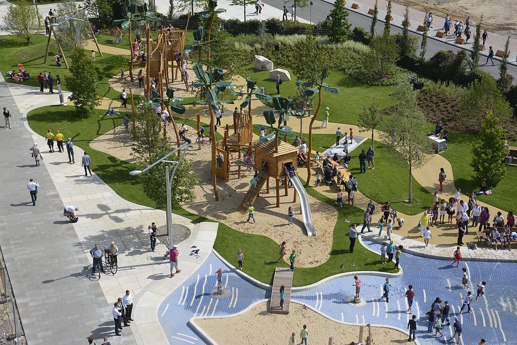

## X by Y by Z arrays

```
##                             vandalised yes  no
## area   natural surveillance
## urban  yes                             911  44
##        no                              538 456
## suburb yes                               3   2
##        no                               43 279
```

Simple extension of the r*c calculation?

## Multilevel discrete data

```
## , , area = urban
##
##           natural surveillance
## vandalised       yes        no
##        yes 0.6287095 0.3712905
##        no  0.0880000 0.9120000
##
## , , area = suburb
##
##           natural surveillance
## vandalised         yes        no
##        yes 0.065217391 0.9347826
##        no  0.007117438 0.9928826
```

## Idea of multilevel discrete modelling

If the data were independent…

then the expected count = joint prob. * n, where

joint prob. = product of the marginal probabilities

$\mu_i,_j = n * marginal_i * marginal_j$

Probability data

|  | No anti-virus software | Anti-virus software | Sum |
| --- | --- | --- | --- |
| Hacked | 0.3 | 0.25 | 0.55 |
| Not hacked | 0.2 | 0.25 | 0.45 |
| Sum | 0.5 | 0.50 | 1.00 |

Probability data

|  | No anti-virus software | Anti-virus software | Sum |
| --- | --- | --- | --- |
| Hacked | 0.3 | 0.25 | 0.55 |
| Not hacked | 0.2 | 0.25 | 0.45 |
| Sum | 0.5 | 0.50 | 1.00 |

$cell[1,2] = 0.50*0.55*1000 = 275$

$cell[2,2] = 0.50*0.45*1000 = 225$

## Towards a linear model

**Log transformation**

$\mu_i,_j = n * marginal_i * marginal_j$

==

$log(\mu_i,_j) = log(n) + log(marginal_i) + log(marginal_j)$

Hence: “loglinear” model

## The Log-Linear Model

- GLM with link function for count data
- count data aptly modelled as a Poisson distrubuted variable

## The poisson distribution

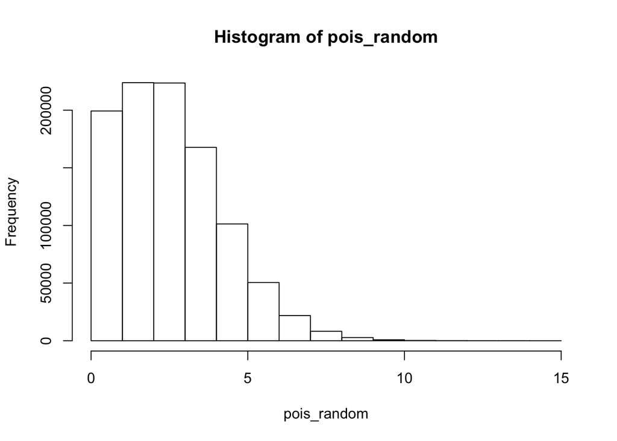

## The loglinear model

```
##   vandalised natural.surveillance   area Freq
## 1        yes                  yes  urban  911
## 2         no                  yes  urban   44
## 3        yes                   no  urban  538
## 4         no                   no  urban  456
## 5        yes                  yes suburb    3
## 6         no                  yes suburb    2
## 7        yes                   no suburb   43
## 8         no                   no suburb  279
```

```r
indep_model = glm(formula = Freq ~ vandalised + natural.surveillance + area
               , data = data3_
               , family = poisson)
```

## The loglinear model

```
##
## Call:
## glm(formula = Freq ~ vandalised + natural.surveillance + area,
##     family = poisson, data = data3_)
##
## Deviance Residuals:
##       1        2        3        4        5        6        7        8
##  14.522  -17.683   -7.817    3.426  -12.440   -8.832   -8.436   19.639
##
## Coefficients:
##                        Estimate Std. Error z value Pr(>|z|)
## (Intercept)             6.29154    0.03667 171.558  < 2e-16 ***
## vandalisedno           -0.64931    0.04415 -14.707  < 2e-16 ***
## natural.surveillanceno  0.31542    0.04244   7.431 1.08e-13 ***
## areasuburb             -1.78511    0.05976 -29.872  < 2e-16 ***
## ---
## Signif. codes:  0 '***' 0.001 '**' 0.01 '*' 0.05 '.' 0.1 ' ' 1
##
## (Dispersion parameter for poisson family taken to be 1)
##
##     Null deviance: 2851.5  on 7  degrees of freedom
## Residual deviance: 1286.0  on 4  degrees of freedom
## AIC: 1343.1
##
## Number of Fisher Scoring iterations: 6
```

## Interpretation

1. Look at the Residual deviance
   - Higher deviance = poorer model fit
   - We can test the H0 of model adequacy

```r
pchisq(1286, 4, lower.tail = F)
```

```
## [1] 3.610223e-277
```

Reject H0 that the model is a good representation.

## Interpretation

2. Look at the fitted values

```r
knitr::kable(cbind(indep_model$data, round(fitted(indep_model), 2)))
```

| vandalised | natural.surveillance | area | Freq | round(fitted(indep_model), 2) |
| --- | --- | --- | --- | --- |
| yes | yes | urban | 911 | 539.98 |
| no | yes | urban | 44 | 282.09 |
| yes | no | urban | 538 | 740.23 |
| no | no | urban | 456 | 386.70 |
| yes | yes | suburb | 3 | 90.60 |
| no | yes | suburb | 2 | 47.33 |
| yes | no | suburb | 43 | 124.19 |
| no | no | suburb | 279 | 64.88 |

## Interpretation

3. Look at the anit-logged coefficients

Coefficient for “vandalised=no”

```r
exp(-0.64931)
```

```
## [1] 0.5224061
```

## The full model

Also called: the saturated model

```r
full_model = glm(formula = Freq ~ vandalised * natural.surveillance * area
               , data = data3_
               , family = poisson)
```

What do you expect?

## The full model

```r
knitr::kable(cbind(full_model$data, round(fitted(full_model), 2)))
```

| vandalised | natural.surveillance | area | Freq | round(fitted(full_model), 2) |
| --- | --- | --- | --- | --- |
| yes | yes | urban | 911 | 911 |
| no | yes | urban | 44 | 44 |
| yes | no | urban | 538 | 538 |
| no | no | urban | 456 | 456 |
| yes | yes | suburb | 3 | 3 |
| no | yes | suburb | 2 | 2 |
| yes | no | suburb | 43 | 43 |
| no | no | suburb | 279 | 279 |

## Loglinear model strategy

- Find a model less complex than the full model
- … where you cannot reject the H0 of model adequacy

## Model selection

```r
step(full_model)
```

```
## Start:  AIC=65.04
## Freq ~ vandalised * natural.surveillance * area
##
##                                        Df Deviance    AIC
## - vandalised:natural.surveillance:area  1  0.37399 63.417
## <none>                                     0.00000 65.043
##
## Step:  AIC=63.42
## Freq ~ vandalised + natural.surveillance + area + vandalised:natural.surveillance +
##     vandalised:area + natural.surveillance:area
##
##                                   Df Deviance    AIC
## <none>                                   0.37  63.42
## - natural.surveillance:area        1    92.02 153.06
## - vandalised:area                  1   187.75 248.80
## - vandalised:natural.surveillance  1   497.37 558.41
```

```
##
## Call:  glm(formula = Freq ~ vandalised + natural.surveillance + area +
##     vandalised:natural.surveillance + vandalised:area + natural.surveillance:area,
##     family = poisson, data = data3_)
##
## Coefficients:
##                         (Intercept)                         vandalisedno
##                              6.8139                              -3.0158
##              natural.surveillanceno                           areasuburb
##                             -0.5249                              -5.5283
## vandalisedno:natural.surveillanceno              vandalisedno:areasuburb
##                              2.8479                               2.0545
##   natural.surveillanceno:areasuburb
##                              2.9860
##
## Degrees of Freedom: 7 Total (i.e. Null);  1 Residual
## Null Deviance:       2851
## Residual Deviance: 0.374     AIC: 63.42
```

## “Best” model

```r
summary(best_model)
```

```
##
## Call:
## glm(formula = Freq ~ vandalised + natural.surveillance + area +
##     vandalised:natural.surveillance + vandalised:area + natural.surveillance:area,
##     family = poisson, data = data3_)
##
## Deviance Residuals:
##        1         2         3         4         5         6         7
##  0.02044  -0.09256  -0.02658   0.02890  -0.33428   0.49134   0.09452
##        8
## -0.03690
##
## Coefficients:
##                                     Estimate Std. Error z value Pr(>|z|)
## (Intercept)                          6.81387    0.03313 205.699  < 2e-16
## vandalisedno                        -3.01575    0.15162 -19.891  < 2e-16
## natural.surveillanceno              -0.52486    0.05428  -9.669  < 2e-16
## areasuburb                          -5.52827    0.45221 -12.225  < 2e-16
## vandalisedno:natural.surveillanceno  2.84789    0.16384  17.382  < 2e-16
## vandalisedno:areasuburb              2.05453    0.17406  11.803  < 2e-16
## natural.surveillanceno:areasuburb    2.98601    0.46468   6.426 1.31e-10
##
## (Intercept)                         ***
## vandalisedno                        ***
## natural.surveillanceno              ***
## areasuburb                          ***
## vandalisedno:natural.surveillanceno ***
## vandalisedno:areasuburb             ***
## natural.surveillanceno:areasuburb   ***
## ---
## Signif. codes:  0 '***' 0.001 '**' 0.01 '*' 0.05 '.' 0.1 ' ' 1
##
## (Dispersion parameter for poisson family taken to be 1)
##
##     Null deviance: 2851.46098  on 7  degrees of freedom
## Residual deviance:    0.37399  on 1  degrees of freedom
## AIC: 63.417
##
## Number of Fisher Scoring iterations: 4
```

## “Best” model

Can we reject the H0 of model adequacy?

```r
pchisq(0.37, 1, lower.tail = F)
```

```
## [1] 0.5430043
```

No!

## Fitted values of the “best” model

| vandalised | natural.surveillance | area | Freq | round(fitted(best_model), 2) |
| --- | --- | --- | --- | --- |
| yes | yes | urban | 911 | 910.38 |
| no | yes | urban | 44 | 44.62 |
| yes | no | urban | 538 | 538.62 |
| no | no | urban | 456 | 455.38 |
| yes | yes | suburb | 3 | 3.62 |
| no | yes | suburb | 2 | 1.38 |
| yes | no | suburb | 43 | 42.38 |
| no | no | suburb | 279 | 279.62 |

## Interpreting the coefficients

```r
coefficients(best_model)
```

```
##                         (Intercept)                        vandalisedno
##                           6.8138656                          -3.0157544
##              natural.surveillanceno                          areasuburb
##                          -0.5248611                          -5.5282675
## vandalisedno:natural.surveillanceno             vandalisedno:areasuburb
##                           2.8478892                           2.0545341
##   natural.surveillanceno:areasuburb
##                           2.9860144
```

## Interpreting the coefficients

```r
vandalisedno:areasuburb
2.0545341
```

```r
exp(2.055)
```

```
## [1] 7.806838
```

Exponentiated interaction ==> OR

> Playgrounds that are in the suburb have estimated odds of not being vandalised that is 7.81 times the estimated odds for playgrounds that are in urban areas. This is independent of “natural surveillance”.
- Log-linear models work in higher dimensions
- Allow you to model count data of 2+ dimensions

Follow the steps [here](https://data.library.virginia.edu/an-introduction-to-loglinear-models/) (https://data.library.virginia.edu/an-introduction-to-loglinear-models/)

### Recap

## Outlook

**Next week:** Reading week

Week 6: Open Science (lecture + tutorial)